# Taller 4

Un granjero quiere plantar trigo, maiz o caña de azucar en 500 acres de tierra. Durante el invierno quiere decidir cuanta tierra dedicar a cada cultivo. Se necesitan 200 toneladas de trigo y 240 de maiz para alimentar el ganado, las cuales pueden ser producidos y su excedente vendido, o compradas en el mercado un 40% más caros que el precio de venta. La tonelada de trigo se vende en un precio aleatorio con media 170, el maiz con un precio aleatorio con media 150 y la caña se vende a un promedio de 36 si la cantidad es inferior a 6000 toneladas y a un promedio de 10 si está por encima de esta cantidad. El problema puede ser modelado como un problema de dos etapas con las variables

- $x_1$ acres dedicados al trigo
- $x_2$ acres dedicados al maiz
- $x_3$ acres dedicados a la caña
- $w_1$ toneladas de trigo vendido
- $y_1$ toneladas de trigo comprado
- $w_2$ toneladas de maiz vendido
- $y_2$ toneladas de maiz comprado
- $w_3$ toneladas de caña vendido a precio alto
- $w_4$ toneladas de caña vendido a precio bajo

donde se busca resolver el problema de optimización

\begin{equation} \begin{split} \min c^{T}x+E_{\xi}[Q(x,\xi)]\\ st. \quad x_1+x_2+x_3\leq 500\\ x_1,x_2,x_3\geq 0 \end{split} \end{equation}

donde $c=(150,230,260)$ es el vector de precios de plantación por acre de cada cultivo, y $Q(x,\xi)$ es el óptimo del problema

\begin{equation} \begin{split} Q(x,\xi)=\min 1.4\xi_1 y_1-\xi_1 w_1+1.4\xi_2 y_2-\xi_2 w_2 -\xi_3 w_3 - \xi_4 w_4\\ st. \quad \xi_5 x_1+y_1-w_1\geq 200\\ \xi_6 x_2+y_2-w_2\geq 240\\ w_3+w_4\leq\xi_7 x_3\\ w_3\leq 6000\\ y,w\geq 0 \end{split} \end{equation}

donde $\xi=(\xi_1,\ldots,\xi_7)$ y las $\xi_i$ son variables aleatorias independientes con distribución

\begin{equation} \xi_1\sim \begin{cases} 170 & \text{ con probabilidad } 0.2 \\ 210 & \text{ con probabilidad } 0.4\\ 130 & \text{ con probabilidad } 0.4 \end{cases} \end{equation}\begin{equation} \xi_2\sim \begin{cases} 150 & \text{ con probabilidad } 0.2 \\ 190 & \text{ con probabilidad } 0.4\\ 110 & \text{ con probabilidad } 0.4 \end{cases} \end{equation}\begin{equation} \xi_3\sim \begin{cases} 36 & \text{ con probabilidad } 0.1 \\ 45 & \text{ con probabilidad } 0.45\\ 27 & \text{ con probabilidad } 0.45 \end{cases} \end{equation}\begin{equation} \xi_4\sim \begin{cases} 10 & \text{ con probabilidad } 0.4 \\ 15 & \text{ con probabilidad } 0.3\\ 5 & \text{ con probabilidad } 0.3 \end{cases} \end{equation}\begin{equation} \xi_5\sim \begin{cases} 2.5 & \text{ con probabilidad } 0.6 \\ 3 & \text{ con probabilidad } 0.2\\ 2 & \text{ con probabilidad } 0.2 \end{cases} \end{equation}\begin{equation} \xi_6\sim \begin{cases} 3 & \text{ con probabilidad } 0.6 \\ 3.4 & \text{ con probabilidad } 0.2\\ 2.6 & \text{ con probabilidad } 0.2 \end{cases} \end{equation}\begin{equation} \xi_7\sim \begin{cases} 20 & \text{ con probabilidad } 0.25 \\ 10 & \text{ con probabilidad } 0.25\\ 5 & \text{ con probabilidad } 0.25\\ 45 & \text{ con probabilidad } 0.25 \end{cases} \end{equation}

lo que resulta en $4*3^6=2916$ escenarios con diferentes probabilidades.

O de otra manera $Q(x,\xi)=min\{q^{T}z |Wz\leq h-Tx, z\geq 0\}$ con $z=(y_1,w_1,y_2,w_2,w_3,w_4)$ , $q=(1.4\xi_1,-\xi_1,1.4\xi_2,-\xi_2,-\xi_3,-\xi_4)$ y

\begin{equation} W=\begin{pmatrix} -1 & 1 & 0 & 0 & 0 & 0\\ 0 & 0 & -1 & 1 & 0 & 0\\ 0 & 0 & 0 & 0 & 1 & 1\\ 0 & 0 & 0 & 0 & 1 & 0 \end{pmatrix} \end{equation}\begin{equation} T=\begin{pmatrix} -\xi_5 & 0 & 0\\ 0 & -\xi_6 & 0\\ 0 & 0 & -\xi_7\\ 0 & 0 & 0\\ \end{pmatrix} \end{equation}\begin{equation} h=\begin{pmatrix} -200\\ -240\\ 0\\ 6000\\ \end{pmatrix} \end{equation}

Construyamos las variables discretas con sus respectivas probabilidades

```julia
using .Iterators
```

```julia
xi1=[170 210 130; 0.2 0.4 0.4]
xi2=[150 190 110; 0.2 0.4 0.4]
xi3=[36 45 27; 0.1 0.45 0.45]
xi4=[10 15 5; 0.4 0.3 0.3]
xi5=[2.5 3.0 2.0; 0.6 0.2 0.2]
xi6=[3.0 3.4 2.6; 0.6 0.2 0.2]
xi7=[20.0 10.0 5.0 45.0; 0.25 0.25 0.25 0.25];
```

Verifiquemos que tienen los valores esperados correctos

```julia
println(sum(xi1[1,:].*xi1[2,:]))
println(sum(xi2[1,:].*xi2[2,:]))
println(sum(xi3[1,:].*xi3[2,:]))
println(sum(xi4[1,:].*xi4[2,:]))
println(sum(xi5[1,:].*xi5[2,:]))
println(sum(xi6[1,:].*xi6[2,:]))
println(sum(xi7[1,:].*xi7[2,:]))
```

```
170.0
150.0
36.0
10.0
2.5
3.0
20.0
```

Y ahora construyamos los respectivos 2916 escenarios posibles

```julia
Ts=Matrix{Float64}[]
qs=Vector{Float64}[]
probs=Float64[]
hs=Vector{Float64}[]
for ind in product(1:3,1:3,1:3,1:3,1:3,1:3,1:4)
    Tn=zeros(4,3)
    Tn[1,1]=-xi5[1,ind[5]]
    Tn[2,2]=-xi6[1,ind[6]]
    Tn[3,3]=-xi7[1,ind[7]]
    qn=[1.4*xi1[1,ind[1]],-xi1[1,ind[1]],1.4*xi2[1,ind[2]],-xi2[1,ind[2]],-xi3[1,ind[3]],-xi4[1,ind[4]]]
    append!(hs,[[-200.0, -240.0, 0.0, 6000.0]])
    append!(Ts,[Tn])
    append!(qs,[qn])
    append!(probs,xi1[2,ind[1]]*xi2[2,ind[2]]*xi3[2,ind[3]]*xi4[2,ind[4]]*xi5[2,ind[5]]*xi6[2,ind[6]]*xi7[2,ind[7]])
end
```

```julia
c=[150.0,230.0,260.0]
A=[1 1 1]
b=[500]
W=[-1.0 1.0 0 0 0 0;0 0 -1.0 1.0 0 0;0 0 0 0 1 1;0 0 0 0 1 0];
```

# L-shaped

```julia
using JuMP
using Mosek;
using MosekTools;
```

```julia
function L_shaped(c,A,b,W,hs,qs,Ts,probs)
    master = Model(Mosek.Optimizer)
    set_silent(master)
    @variable(master, x[1:length(c)]>=0)
    @variable(master, theta)
    @constraint(master,A*x.<=b)
    @objective(master, Min, c'*x)
    seguir=true
    optimize!(master)
    xv=value.(x)
    thetav=-Inf
    #println("Primero", xv)
    k=1
    while seguir
        pis=Array{Float64}[]
        for i in 1:length(Ts)
            esclavo=Model(Mosek.Optimizer)
            set_silent(esclavo)
            @variable(esclavo, y[1:size(W)[2]]>=0)
            @constraint(esclavo,pi,W*y.<=hs[i].-Ts[i]*xv)
            @objective(esclavo, Min, qs[i]'*y)
            #print(esclavo)
            optimize!(esclavo)
            append!(pis,[dual.(pi)])
        end
        Et=zeros(length(c))
        e=0.0
        for i in 1:length(Ts)
            Et+=probs[i]*transpose(Ts[i])*pis[i]
            e+=probs[i]*transpose(pis[i])*hs[i]
        end
        #println(Et)
        #println(e)
        if abs(e-Et'*xv-thetav)<1e-3
            seguir==false
            println("Acaba con las cotas de optimo ",e-Et'*xv +c'*xv,"<f^*<",thetav+c'*xv)
            return xv
        else
            @constraint(master,Et'*x+theta>=e)
            @objective(master, Min, c'*x+theta)
            println("Iteracion ",k)
            #println("Sigue porque wv es ",e-Et'*xv," y theta es ", thetav)
            println("Cotas: ",e-Et'*xv +c'*xv," <f*< ",thetav+c'*xv)
            optimize!(master)
            xv=value.(x)
            thetav=value.(theta)
            #readline()
        end
        k+=1
    end
end
```

```
L_shaped (generic function with 1 method)
```

Ahora evaluamos la velocidad y precisión del método

```julia
@time L_shaped(c,A,b,W,hs,qs,Ts,probs)
```

```
Iteracion 1
Cotas: 98000.00000000047 <f*< -Inf
Iteracion 2
Cotas: 1249.9999999979918 <f*< -132000.00000000227
Iteracion 3
Cotas: -72253.84707233954 <f*< -127269.23063571572
Iteracion 4
Cotas: -57017.64694917368 <f*< -115923.52921694727
Iteracion 5
Cotas: -59508.24294854705 <f*< -97192.26319299375
Iteracion 6
Cotas: -78403.72250304617 <f*< -92314.38240062208
Iteracion 7
Cotas: -87382.66666573922 <f*< -87766.66666553765
Iteracion 8
Cotas: -87241.5384596926 <f*< -87625.53845479152
Iteracion 9
Cotas: -87128.57648088655 <f*< -87426.50751531965
Acaba con las cotas de optimo -87382.66666665515<f^*<-87382.66666665445
 13.584293 seconds (57.92 M allocations: 2.249 GiB, 2.97% gc time)
```

```
3-element Vector{Float64}:
 286.6666666667749
  79.99999999979212
 133.33333333340516
```

Vemos que el método converge agregando 9 cortes de optimalidad y tarde aproximadamente 13 segundos de cálculo. Halla un óptimo de primera etapa correspondiente a plantar 286.66 acres de trigo, 80 acres de maiz y 133.333 acres de caña de azucar. La respuesta varía al caso determinista del libro por la nueva incertidumbre introducida, particularmente la gran varianza añadida en el el yield de la caña, por lo que ya no es tan buena idea plantear las 300 que sugiere el problema determinista a pesar que los valores esperados de las variables sean los mismos.

# L-shaped multicorte

Ahora implementemos el método multicorte, añadiendo en cada iteración más de un corte.

```julia
function L_shaped_multicorte(c,A,b,W,hs,qs,Ts,probs)
    master = Model(Mosek.Optimizer)
    set_silent(master)
    @variable(master, x[1:length(c)]>=0)
    @variable(master, theta[1:length(Ts)])
    @constraint(master,A*x.<=b)
    @objective(master, Min, c'*x)
    seguir=true
    optimize!(master)
    xv=value.(x)
    thetav=repeat([-Inf], length(Ts))
    #println("Primero", xv)
    k=1
    while seguir
        cuan=0
        aux=[]
        for i in 1:length(Ts)
            esclavo=Model(Mosek.Optimizer)
            set_silent(esclavo)
            @variable(esclavo, y[1:size(W)[2]]>=0)
            @constraint(esclavo,pi,W*y.<=hs[i].-Ts[i]*xv)
            @objective(esclavo, Min, qs[i]'*y)
            #print(esclavo)
            optimize!(esclavo)
            E=probs[i]*dual.(pi)'*Ts[i]
            e=probs[i]*dual.(pi)'*hs[i]
            append!(aux,e-(E*xv)[1])
            if thetav[i]<e-(E*xv)[1]
                #append!(aux,e-(E*xv)[1])
                @constraint(master,E*x+theta[i]>=e)
                cuan+=1
            end
        end
        if cuan==0
            seguir==false
            println("Cotas finales: ",c'*xv+sum(aux)," <f*< ",c'*xv+sum(thetav))
            return xv
        else
            @objective(master, Min, c'*x+sum([theta[i] for i in 1:length(Ts)]))
            println("Iteracion ",k)
            println("Sigue porque hay ",cuan," menores")
            println("Cotas: ",c'*xv+sum(aux)," <f*< ",c'*xv+sum(thetav))
            optimize!(master)
            xv=value.(x)
            #println(xv)
            thetav=value.(theta)
            #readline()
        end
        k+=1
    end
end
```

```
L_shaped_multicorte (generic function with 1 method)
```

Y evaluemos su funcionamiento

```julia
@time L_shaped_multicorte(c,A,b,W,hs,qs,Ts,probs)
```

```
Iteracion 1
Sigue porque hay 2916 menores
Cotas: 98000.00000000028 <f*< -Inf
Iteracion 2
Sigue porque hay 1458 menores
Cotas: 1249.9999999998836 <f*< -132000.00000000006
Iteracion 3
Sigue porque hay 2916 menores
Cotas: -77766.66666591485 <f*< -126499.99999990457
Iteracion 4
Sigue porque hay 2916 menores
Cotas: -75855.99999869906 <f*< -113055.99999885773
Iteracion 5
Sigue porque hay 2187 menores
Cotas: -81746.10777909202 <f*< -96070.36604501666
Cotas finales: -87382.66664056506 <f*< -87382.66663146898
  8.310601 seconds (36.26 M allocations: 1.423 GiB, 2.59% gc time)
```

```
3-element Vector{Float64}:
 286.6666665944781
  80.00000001171964
 133.33333331334734
```

Vemos que converge a lo mismo que L-shaped y más rápido, en 5 iteraciones completas y 8 segundos.

# Subgradiente proyectado

Ahora usemos un método de subgradiente proyectado para resolver el problema

Si queremos minimizar la función $f(x)=c^{T}x+D(x)$ restringido al conjunto $K_1$ con $D(x)=\sum_{i=1}^{N}p_i Q(x,s_i)$, podríamos implementar un método de subgradiente proyectado, realizando iteraciones de la forma \begin{equation} x_{k+1}=\Pi_{K_1}(x_{k}-\alpha_k g_k) \end{equation} donde $\Pi_{K_1}$ es la proyección en $K_1$, $g_k$ es cualquier elemento del subgradiente de $f(x)$ y $\alpha_k$ es el tamaño de paso, que se puede elegir como se suguiere en las notas por el paso de Polyak, dado por \begin{equation} \alpha_k=\frac{f(x_k)-f^*}{||g_k||_2^2} \end{equation} donde $f^*$ es el óptimo real del problema, que podríamos tomar de los métodos usados anteriormente, o aproximarlo mediante \begin{equation} \alpha_k=\frac{f(x_k)-f_{k}^{best}+\gamma_k}{||g_k||_2^2} \end{equation} con $f_{k}^{best}$ el mejor valor óptimo encontrado hasta el momento y $\gamma_k \to 0$.

Otra manera de escoger el paso sería una sucesión escogida a priori que podría ser de la forma \begin{equation} \alpha_k=\frac{1}{k}. \end{equation}

Los subgradientes los podemos encontrar usando que \begin{equation} \partial D(x)=\sum_{i=1}^{N}p_i \partial Q(x,s_i) \end{equation} y que \begin{equation} \partial Q(x,s_i)=-T_i^{T}\pi \end{equation} donde $\pi$ es una solución óptima del problema dual \begin{equation} \begin{split} \max \pi^{T}(h_i-T_ix)\\ s.t \quad W^T \pi\leq q_i.\\ \pi\leq 0 \end{split} \end{equation} Así, tenemos que \begin{equation} \partial f(x)=c+\partial \mathcal{D}(x) \end{equation}

Finalmente, la proyección el simplex ampliado en cada iteración la podemos hacer con el algoritmo que sugirió el grupo de Mateo, escalando las variables para tener el simplex de probabilidad y desescalando para obtener la proyección en el espacio real.

```julia
using LinearAlgebra
using PyPlot
using Clp
```

```julia
function proyectar_en_K1(x0,m)
    x=x0./m
    if abs(sum(x)-1.0)>1e-5 || sum(x.<=0)>0
        u=sort(x, rev=true)
        rho=findlast((u.+((1.0.-cumsum(u))./(1:length(x)))).>0)
        lambda=(1.0-sum(u[1:rho]))/rho
        return clamp.(x .+lambda,0,Inf).*m
    else
        return x0
    end

end

function proyectar(x0)
    model = Model(Mosek.Optimizer)
    set_silent(model)
    @variable(model, x[1:length(x0)])
    @constraint(model,ones(length(x0))'*x<=120)
    @constraint(model,x[1]>=40)
    @constraint(model,x[2]>=20)
    @objective(model, Min, x[1]^2+x[2]^2-2*x[1]x0[1]-2*x[2]*x0[2])
    optimize!(model)
    return value.(x)
end

function Q(xl,W,hi,qi,Ti)
    model = Model(Clp.Optimizer)
    set_silent(model)
    @variable(model, z[1:size(W)[2]]>=0)
    @constraint(model,W*z+Ti*xl.<=hi)
    @objective(model, Min, qi'*z)
    optimize!(model)
    return objective_value(model)
end

function f(x,c,W,hs,qs,Ts,probs)
    resp=0.0
    for i in 1:length(Ts)
        resp+=probs[i]*Q(x,W,hs[i],qs[i],Ts[i])
    end
    return sum(c.*x)+resp
end

function paso_polyak(k,f_xk,g_k)
    return (f_xk-fopt)/(norm(g_k)^2)
end

function paso_inverso(k,f_xk,g_k)
    return 2.0/k
end

function subgradiente_proyectado(c,A,b,W,hs,qs,Ts,probs,tam_paso)
    xk=proyectar_en_K1([0.0,0.0,0.0],500)
    k=1
    x_best=proyectar_en_K1([00.0,00.0,0.0],500)
    f_best=f(x_best,c,W,hs,qs,Ts,probs)
    f_xk=f(xk,c,W,hs,qs,Ts,probs)
    fs=[f_xk]
    xks=[xk]
    f_bs=[f_best]
    while k<100
        dQs=[]
        #valQ=zeros(length(Ts))
        for i in 1:length(Ts)
            model = Model(Clp.Optimizer)
            set_silent(model)
            @variable(model, pi[1:length(hs[1])]<=0)
            @constraint(model,transpose(W)*pi.<=qs[i])
            @objective(model, Max, pi'*(hs[i]-Ts[i]*xk))
            optimize!(model)
            append!(dQs,[-transpose(Ts[i])*value.(pi)])
            #valQ[i]=objective_value(model)
        end
        #f_xk=sum(c.*xk)+sum(probs.*valQ)

        dD=sum(probs.*dQs)
        gk=c+dD

        alpha_k=tam_paso(k,f_xk,gk)
        xn=xk-alpha_k.*gk
        xk=proyectar_en_K1(xn,500)
        f_xk=f(xk,c,W,hs,qs,Ts,probs)
        if f_xk<f_best
            f_best=f_xk
            x_best=xk
        end
        append!(fs,f_xk)
        append!(xks,[xk])
        append!(f_bs,f_best)
        if (k-1)%5==0
        println("Iteracion ",k)
        println("alphak: ",alpha_k)
        println("xk: ",xk," f_xk:",f_xk)
        println("xbest:",x_best," f_best:",f_best)
        end
        k+=1
    end
    return fs,xks,f_bs
end
```

```
subgradiente_proyectado (generic function with 1 method)
```

Evaluemos en primer lugar el desempeño con tamaño de paso $\alpha_k=\frac{2}{k}$

```julia
@time fs,xks,f_bs=subgradiente_proyectado(c,A,b,W,hs,qs,Ts,probs,paso_inverso);
```

```
Iteracion 1
alphak: 2.0
xk: [275.0000000000012, 165.00000000000165, 59.99999999999722] f_xk:-69524.99999999936
xbest:[166.66666666666666, 166.66666666666666, 166.66666666666666] f_best:-79416.66666666654
Iteracion 6
alphak: 0.3333333333333333
xk: [245.83333333333496, 96.33333333333532, 157.83333333332965] f_xk:-84234.5833333336
xbest:[245.83333333333496, 96.33333333333532, 157.83333333332965] f_best:-84234.5833333336
Iteracion 11
alphak: 0.18181818181818182
xk: [276.623379028381, 92.27687109187391, 131.09974987974508] f_xk:-86677.26419576633
xbest:[276.623379028381, 92.27687109187391, 131.09974987974508] f_best:-86677.26419576633
Iteracion 16
alphak: 0.125
xk: [276.29384606134835, 82.76904142154436, 140.93711251710732] f_xk:-86499.3572185786
xbest:[276.623379028381, 92.27687109187391, 131.09974987974508] f_best:-86677.26419576633
Iteracion 21
alphak: 0.09523809523809523
xk: [276.30889463048385, 80.98771572167365, 142.70338964784244] f_xk:-86351.87797868103
xbest:[281.44286566919163, 85.1180610293875, 133.43907330142093] f_best:-87249.48976759767
Iteracion 26
alphak: 0.07692307692307693
xk: [283.60370183294356, 86.97121877900284, 129.4250793880536] f_xk:-86493.72467984972
xbest:[281.44286566919163, 85.1180610293875, 133.43907330142093] f_best:-87249.48976759767
Iteracion 31
alphak: 0.06451612903225806
xk: [282.6868892467466, 84.79565531734735, 132.517455435906] f_xk:-87117.59265908922
xbest:[281.44286566919163, 85.1180610293875, 133.43907330142093] f_best:-87249.48976759767
Iteracion 36
alphak: 0.05555555555555555
xk: [281.73477807904726, 83.37685223045604, 134.88836969049666] f_xk:-87135.13117518663
xbest:[281.44286566919163, 85.1180610293875, 133.43907330142093] f_best:-87249.48976759767
Iteracion 41
alphak: 0.04878048780487805
xk: [283.08411323577025, 78.615580891476, 138.30030587275374] f_xk:-86732.14902974131
xbest:[281.44286566919163, 85.1180610293875, 133.43907330142093] f_best:-87249.48976759767
Iteracion 46
alphak: 0.043478260869565216
xk: [286.8952729138258, 82.15490906657776, 130.94981801959636] f_xk:-86890.42949783942
xbest:[284.9923743631012, 81.28679312454878, 133.72083251235006] f_best:-87310.38482855819
```

[output cut: 26 more lines]

```
xk: [285.2764437983273, 81.94503337121338, 132.7785228304593] f_xk:-87233.73492940023
xbest:[285.31999070669843, 81.10709957947506, 133.57290971382653] f_best:-87330.56323577219
Iteracion 86
alphak: 0.023255813953488372
xk: [284.97886308814395, 81.32494374846533, 133.69619316339075] f_xk:-87312.1255737222
xbest:[285.31999070669843, 81.10709957947506, 133.57290971382653] f_best:-87330.56323577219
Iteracion 91
alphak: 0.02197802197802198
xk: [285.53894204602227, 79.21018990601291, 135.25086804796484] f_xk:-87110.02967493009
xbest:[285.31999070669843, 81.10709957947506, 133.57290971382653] f_best:-87330.56323577219
Iteracion 96
alphak: 0.020833333333333332
xk: [284.5194343614547, 80.30389244385461, 135.17667319469064] f_xk:-87177.27499140747
xbest:[285.31999070669843, 81.10709957947506, 133.57290971382653] f_best:-87330.56323577219
198.632718 seconds (1.13 G allocations: 44.130 GiB, 3.37% gc time, 0.17% compilation time)
```

Con 100 iteraciones el algoritmo parece estar convergiendo a la misma solución encontrada anteriormente, pero a una tasa muy lenta y cada iteración es muy costosa, por lo que le toma casi 200 segundos alcanzar este resultado, que está muy lejos de ser preciso. Veamos la siguiente gráfica de convergencia comparada con el óptimo calculado con los métodos anteriores

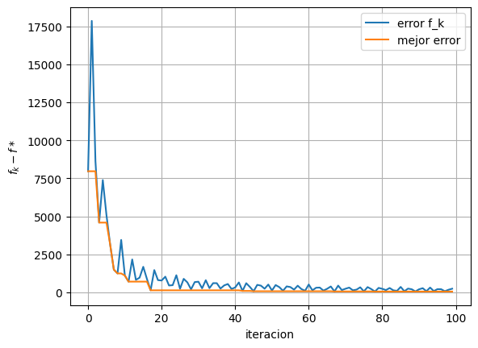

```
PyObject <matplotlib.legend.Legend object at 0x7f5167a2fa30>
```

```julia
plot(fs.-fopt,label="error f_k")
plot(f_bs.-fopt,label="mejor error")
xlabel("iteracion")
ylabel(L"f_k-f*")
grid()
legend()
```

Vemos que el error disminuye, pero disminuye lentamente. Esto se debe a la no suavidad de la función y al inconveniente que supone proyectar. Encontrar una esquina de una función no suave y proyectando en cada paso no es una buena forma de hallar óptimos.

Ahora examinemos el comportamiento con el paso de Polyak con el óptimo verdadero

```julia
@time fspol,xkspol,f_bspol=subgradiente_proyectado(c,A,b,W,hs,qs,Ts,probs,paso_polyak);
```

```
Iteracion 1
alphak: 0.05237989549851007
xk: [169.50391100616932, 166.62301675375127, 163.87307224007938] f_xk:-79719.37881273558
xbest:[169.50391100616932, 166.62301675375127, 163.87307224007938] f_best:-79719.37881273558
Iteracion 6
alphak: 0.043155764332337976
xk: [182.15252303584634, 166.42842272252565, 151.41905424162806] f_xk:-81068.88841928601
xbest:[182.15252303584634, 166.42842272252565, 151.41905424162806] f_best:-81068.88841928601
Iteracion 11
alphak: 0.03555600822382748
xk: [192.57370686389444, 166.2680968174789, 141.15819631862658] f_xk:-82180.74857078603
xbest:[192.57370686389444, 166.2680968174789, 141.15819631862658] f_best:-82180.74857078603
Iteracion 16
alphak: 0.02929457374632867
xk: [201.1597139390712, 166.13600440093788, 132.7042816599909] f_xk:-82912.81186504677
xbest:[199.57292452781172, 166.1604165457265, 134.26665892646182] f_best:-82927.51125539048
Iteracion 21
alphak: 0.027678350027865246
xk: [204.6538140441327, 163.4853593695045, 131.8608265863628] f_xk:-82902.55815315533
xbest:[203.15457008429, 163.50842466119437, 133.33700525451565] f_best:-83173.30857877404
Iteracion 26
alphak: 0.012478812648099392
xk: [205.94227809509024, 159.63197891077755, 134.42574299413218] f_xk:-83269.47378803806
xbest:[205.94227809509024, 159.63197891077755, 134.42574299413218] f_best:-83269.47378803806
Iteracion 31
alphak: 0.026538994969004578
xk: [209.2636127009861, 157.22129581057385, 133.51509148844005] f_xk:-83499.9563954111
xbest:[209.2636127009861, 157.22129581057385, 133.51509148844005] f_best:-83499.9563954111
Iteracion 36
alphak: 0.02514126433005933
xk: [212.3450700056403, 154.8067099851719, 132.84822000918777] f_xk:-83562.5516525153
xbest:[212.3450700056403, 154.8067099851719, 132.84822000918777] f_best:-83562.5516525153
Iteracion 41
alphak: 0.023748642282832567
xk: [215.34695103336614, 152.54082991516242, 132.1122190514714] f_xk:-83551.01487918763
xbest:[214.06056624304608, 152.56062045039812, 133.37881330655586] f_best:-83770.9434447733
Iteracion 46
alphak: 0.010676638934216484
xk: [216.45648122939255, 149.2444647150265, 134.29905405558102] f_xk:-83854.40612969818
xbest:[216.45648122939255, 149.2444647150265, 134.29905405558102] f_best:-83854.40612969818
```

[output cut: 26 more lines]

```
xk: [232.40051369918785, 135.14840563992303, 132.45108066088912] f_xk:-84570.28761206858
xbest:[231.45480599701673, 135.16295498918717, 133.38223901379607] f_best:-84727.44678161129
Iteracion 86
alphak: 0.007837980385650832
xk: [233.21766536409072, 132.72865255181475, 134.0536820840945] f_xk:-84789.15328561001
xbest:[233.21766536409072, 132.72865255181475, 134.0536820840945] f_best:-84789.15328561001
Iteracion 91
alphak: 0.016730454228194937
xk: [235.3138808742649, 131.21379326223902, 133.47232586349614] f_xk:-84934.96634025153
xbest:[235.3138808742649, 131.21379326223902, 133.47232586349614] f_best:-84934.96634025153
Iteracion 96
alphak: 0.015846741976435676
xk: [237.25800820525308, 129.69560765116424, 133.04638414358269] f_xk:-84980.32264574846
xbest:[237.25800820525308, 129.69560765116424, 133.04638414358269] f_best:-84980.32264574846
205.346630 seconds (1.13 G allocations: 44.095 GiB, 3.27% gc time, 0.11% compilation time)
```

En este caso vemos que desde el principio los pasos de este estilo son muy pequeños, por lo que la convergencia es aún más lenta, aún cuando el paso se está calculando con el óptimo verdadero. No sé por qué sucede esto. En las mismas 100 iteraciones no se alcanzó una convergencia parecida a la que se obtuvo con el paso elegido a priori. Veamos la gráfica del error absoluto

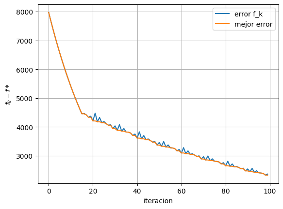

```
PyObject <matplotlib.legend.Legend object at 0x7f516797beb0>
```

```julia
plot(fspol.-fopt,label="error f_k")
plot(f_bspol.-fopt,label="mejor error")
xlabel("iteracion")
ylabel(L"f_k-f*")
grid()
legend()
```

Se muestra una convergencia, pero mucho más lenta.

Para estos métodos de descenso de gradiente no encontré un criterio de parada del algoritmo con alguna útilidad práctica, pues el tiempo de computo se extendía mucho y no se obtienen soluciones con la precisión suficiente.

# Resolver forma extendida

Finalmente, decidí probar resolviendo el sistema completo directamente, esperando que la optimización de un solver profesional en un problema grande le ganara a mi implementación con algoritmos más especializados pero no optimizados en código.

```julia
function forma_extendida(c,A,b,W,hs,qs,Ts,probs)
    master = Model(Mosek.Optimizer)
    set_silent(master)
    @variable(master, x[1:length(c)]>=0)
    @variable(master, y[1:length(Ts),1:size(W)[2]]>=0)
    @constraint(master,A*x.<=b)
    @constraint(master,cs[k=1:length(Ts)],W*y[k,:]+Ts[k]*x.<=hs[k])
    @objective(master, Min, (c'*x)+sum([probs[k]*(qs[k]'*y[k,:]) for k in 1:length(Ts)]))
    optimize!(master)
    return value.(x),objective_value(master)
end
```

```
forma_extendida (generic function with 1 method)
```

```julia
@time xsol,fopt=forma_extendida(c,A,b,W,hs,qs,Ts,probs)
```

```
  0.163808 seconds (996.54 k allocations: 78.657 MiB, 13.23% gc time)
```

```
([286.6666666315809, 80.00000003088344, 133.333333336458], -87382.66664894932)
```

En efecto, el tiempo de solución es un orden de magnitud menor a los métodos que implementé y se obtienen las mismas respuestas. El tamaño del problema permite resolverse directamente con programación lineal en el problema grande, lo que está muy optimizado en un solver comercial como Mosek.

# Comparación

# Variables Continuas y estimación de la brecha de óptimalidad

Ahora supongamos que las variables $\xi_i$ se distribuyen como variables aleatorias normales truncadas a los valores positivos:

- $\xi_1 \sim \mathcal{N}_+(170,30)$
- $\xi_2 \sim \mathcal{N}_+(150,30)$
- $\xi_3 \sim \mathcal{N}_+(36,5)$
- $\xi_4 \sim \mathcal{N}_+(10,5)$
- $\xi_5 \sim \mathcal{N}_+(2.5,1)$
- $\xi_6 \sim \mathcal{N}_+(3,1)$
- $\xi_7 \sim \mathcal{N}_+(20,10)$

Construyamos entonces una muestra iid de la incertidumbre de tamaño $n=3000$, asignando a todos los escenarios la misma probabilidad

```julia
using Distributions
xid1=Truncated(Normal(170, 30),0,1000)
xid2=Truncated(Normal(150, 30),0,1000)
xid3=Truncated(Normal(36, 5),0,1000)
xid4=Truncated(Normal(10, 5),0,1000)
xid5=Truncated(Normal(2.5, 1),0,1000)
xid6=Truncated(Normal(3, 1),0,1000)
xid7=Truncated(Normal(20, 10),0,1000)
```

```
WARNING: using Distributions.probs in module Main conflicts with an existing identifier.
```

```
Truncated(Normal{Float64}(μ=20.0, σ=10.0); lower=0.0, upper=1000.0)
```

```julia
function generar_muestra(n)
    Ts=[]
    qs=[]
    probs=[]
    hs=[]
    for i in 1:n
        Tn=zeros(4,3)
        Tn[1,1]=-rand(xid5)
        Tn[2,2]=-rand(xid6)
        Tn[3,3]=-rand(xid7)
        xi1a=rand(xid1)
        xi2a=rand(xid2)
        xi3a=rand(xid3)
        xi4a=rand(xid4)
        qn=[1.4*xi1a,-xi1a,1.4*xi2a,-xi2a,-xi3a,-xi4a]
        append!(hs,[[-200.0, -240.0, 0.0, 6000.0]])
        append!(Ts,[Tn])
        append!(qs,[qn])
        append!(probs,1.0/n)
    end
    return Ts,qs,probs,hs
end
```

```
generar_muestra (generic function with 1 method)
```

```julia
c=[150.0,230.0,260.0]
A=[1 1 1]
b=[500]
W=[-1.0 1.0 0 0 0 0;0 0 -1.0 1.0 0 0;0 0 0 0 1 1;0 0 0 0 1 0]
Ts,qs,probs,hs=generar_muestra(3000);
```

Y resolvamos el problema con el método directo implementado anteriormente

```julia
@time xhat,obj=forma_extendida(c,A,b,W,hs,qs,Ts,probs)
```

```
  0.535635 seconds (2.12 M allocations: 139.473 MiB, 6.87% gc time, 67.25% compilation time: 11% of which was recompilation)
```

```
([194.03793042705377, 84.87477257430977, 221.08729698863152], -99110.83116706034)
```

Con esta muestra obtuvimos la solución óptima de variables de primera etapa de $\hat{x}=(194.03,84.87,221.08)$

```julia
function calcular_Qs(xhat,c,W,hs,qs,Ts)
    Qs=[]
    for i in 1:length(Ts)
        append!(Qs,Q(xhat,W,hs[i],qs[i],Ts[i]))
    end
    return Qs
end
```

```
calcular_Qs (generic function with 1 method)
```

Generemos ahora otra muestra de tamaño $N=15000$ para calcular estimadores de $\mathcal{D}(\hat{x})$ y usemola para cálcular su media y varianza

```julia
Ts,qs,probs,hs=generar_muestra(15000);
```

```julia
Qs=calcular_Qs(xhat,c,W,hs,qs,Ts);
```

La media es

```julia
mean(Qs)
```

```
-203776.71512030283
```

Y su varianza es

```julia
var(Qs)
```

```
5.832118936030359e9
```

Lo que corresponde a un valor de $f(\hat{x})$ de

```julia
f(xhat,c,W,hs,qs,Ts,probs)
```

```
-97667.1306471095
```

Por el teorema del limite centra esto permite estimar una 99%-cota para $c^{T}\hat{x}+\mathcal{D}(\hat{x})$

Esta cota superior es

\begin{equation} c^{T}\hat{x}+\mathcal{D}(\hat{x})+z_{\alpha}\frac{\hat{\sigma}}{\sqrt{N}} \end{equation}

que corresponde al valor

```julia
cotaSup=sum(c.*xhat)+mean(Qs)+(2.57*(std(Qs))/(15000^0.5))
```

```
-96064.62089964887
```

Ahora, podemos estimar $E[\hat{f}]$ a través de una muestra de muchos problemas como el anterior con diferentes muestras de la incertidumbre. Esta estimación sirve de cota inferior para el óptimo verdadero del problema $f^*$

```julia
function muestrear_optimos(n,M)
    opts=[]
    for i in 1:M
        Ts,qs,probs,hs=generar_muestra(n)
        xhat,obj=forma_extendida(c,A,b,W,hs,qs,Ts,probs)
        append!(opts,obj)
    end
    return opts
end
```

```
muestrear_optimos (generic function with 1 method)
```

En este caso sampleemos 300 muestras diferentes de la incertidumbre, cada una de tamaño 3000 y calculemos la cota inferior para $E[\hat{f}]$ que a su vez sirve de cota inferior para $f^*$

```julia
opts=muestrear_optimos(3000,300)
```

```
300-element Vector{Any}:
  -98637.33984393258
  -99957.54172705658
  -97412.6914669939
  -97590.48622735092
  -97528.11780925773
  -98728.58624397987
  -97310.6201885208
  -97551.82350025931
 -101969.67781992335
  -99069.45706651392
  -97787.64975093585
  -98219.09896870826
  -99357.42097555634
       ⋮
 -102386.7849317521
  -98833.2203721907
 -100353.78239151543
  -99213.29896237268
  -97066.91231174138
  -99926.70453196877
  -97841.84129892691
 -101467.40583112126
  -97532.56947671963
  -96236.15252470491
  -98073.23128226341
 -101522.28992106926
```

Podemos calcular los estadisticos $\bar{\hat{f}}$ y $\sigma_{\hat{f}}$ y por lo tanto,la cota inferior $\bar{f^*}-z_\alpha\frac{\sigma}{\sqrt{M}}$, que resulta ser

```julia
cotainf=mean(opts)-2.57*std(opts)/(300^0.5)
```

```
-98932.87271568403
```

Por lo tanto, un intervalo de confianza al 98% para la brecha de optimalidad $c^{T}\hat{x}+\mathcal{D}(\hat{x})-f^*$ sería [0,2868.25]

```julia
cotaSup-cotainf
```

```
2868.251816035161
```

Si cambiamos los parámetros por $n=4000,N=16000,M=500$

```julia
function construir_intervalo(n,N,M,c,A,b,W)
    Ts,qs,probs,hs=generar_muestra(n)
    xhat,obj=forma_extendida(c,A,b,W,hs,qs,Ts,probs)
    Ts,qs,probs,hs=generar_muestra(N);
    Qs=calcular_Qs(xhat,c,W,hs,qs,Ts);
    cotaSup=sum(c.*xhat)+mean(Qs)+(2.57*(std(Qs))/(N^0.5))
    opts=muestrear_optimos(n,M)
    cotainf=mean(opts)-2.57*std(opts)/(M^0.5)
    return xhat,cotaSup,cotainf,cotaSup-cotainf
end
```

```
construir_intervalo (generic function with 1 method)
```

```julia
xhat,cotaSup,cotainf,maxInter=construir_intervalo(4000,16000,500,c,A,b,W)
```

```
([198.18196765811535, 82.41876848367197, 219.3992638582098], -98709.72191841621, -98916.59558909627, 206.8736706800555)
```

entonces el intervalo de confianza sería $[0,206.87]$ que es mejor que el que se obtuvo anteriormente. Incrementar estos valores de $n,N,M$ no sería práctico, pues el cálculo toma aproximadamente 5 minutos con estos parámetros y cada minuto de computo emite aproximadente 1 g de CO2 a la atmosfera por la energía necesaría para ejecutarlo.

# Conclusiones

- Los métodos L-shape y L-shape multicorte son maneras efectivas de resolver problemas de 2 etapas, aún cuando la implementación no es la mejor, proporcionan tiempos de computo aceptables para problemas pequeños.
- Los métodos de descenso de gradiente proyectado no son tan buenos en esta situación por la naturaleza del óptimo a encontrar. No proporcionan la precisión necesaria en las soluciones, ni son eficientes computacionalmente. Sin embargo, siguen siendo robustos y podrían implementarse para obtener soluciones aproximadas en problemas más dificiles.
- Resolver el sistema directamente a veces puede ser buena idea, mientras el tamaño del problema lo permita. Esto ya que se está usando el código altamente eficiente que existe para resolver problemas de programación lineal y se evitan deficiencias en la implementación propia.
- Se pueden establecer intervalos de confiana para soluciones óptimas de problemas con incertidumbre continua mediante muestreo.